# **Personal Activity Prediction Model**

## 2.0 EXPLORATORY ANALYSIS ON DATA

Two datasets are provided, within the current report they are designated as the training master dataset and the validation datset. The training master data set is cleaned and prepared, and then partitioned to training and test dataset for model building and testing. The final model is then applied to the validation dataset provided.

### *2.1 Reading and Cleaning Input Data*

```r
# Read the raw data (Master Training dataset and Validation dataset)
ReadRawTrgData<- read.csv("pml-training.csv",na.strings=c("","NA","NULL","#DIV/0!"))
ReadRawValidationData<- read.csv("pml-testing.csv",na.strings=c("","NA","NULL","#DIV/0!"))

# Remove majority of NA
CleanTrgData<- ReadRawTrgData[,colSums(is.na(ReadRawTrgData))==0]
# Remove the first 7 variables as they are references to user, timestamp and the windows
Subset1TrgData<-CleanTrgData[,-(1:7)]

# Check for nearzero Var
NearZero <- nearZeroVar(Subset1TrgData[,1:52])
CountNearZero <- length(NearZero)

# Check for Strongly Correlated Variables (Correlation Coeff > 0.75)
CorrMatrix<- abs(cor(Subset1TrgData[,1:52]))
DropStrongCorrCols<- findCorrelation(CorrMatrix,cutoff=0.75,verbose=FALSE)

# Now we have a cleaned master training dataset for building the model
Training.Dataset<- Subset1TrgData[,-DropStrongCorrCols]

# Now Partition the master training dataset
inTrain <- createDataPartition(y=Training.Dataset$classe, p=0.7, list=FALSE)
Training <- Training.Dataset[inTrain,]
Testing <- Training.Dataset[-inTrain,]
```

It is found that there are a total of **160** columns. By removing those columns having “NA” values, and also the first 7 columns, which are the data description columns and time stamps, the total number of variables (or columns) is **53**. The total number of rows in the training dataset is **19622**.

In addition there are **0** columns with near zero variation. Further, with eliminating variables which are strongly correlated, we get a total of **31** predictors.

Finally, the master training dataset is partitioned into test and training sets to develop and test the models to be built, before applying the same on the validation dataset. The number of rows in the training dataset is **13737** and the number of rows in the testing dataset is **5885**.

### *2.2 Data Exploration*

The accelerometers are on the belt, arm, forearm and the dumbbell. Feature plots were generated to understand the relationship of the selected variables, two examples of the feature plots are shown below (Belt and dumbbell).

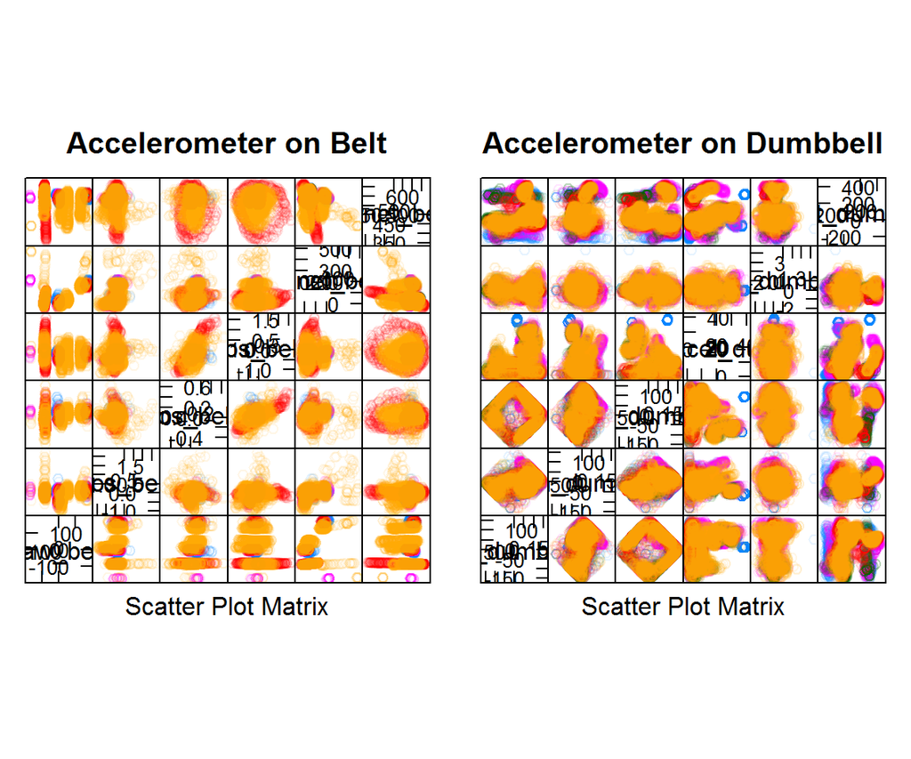

```r
# Generate feature plots using caret package.
BeltColumns <- grep("belt",names(Training))
DumbbellColumns <- grep("dumbbell",names(Training))
BCGraph<-featurePlot(x=Training[,BeltColumns],y=Training$classe,plot="pairs",alpha=.1, main="Accelerometer on Belt")
DCGraph<-featurePlot(x=Training[,DumbbellColumns],y=Training$classe,plot="pairs",alpha=.1, main="Accelerometer on Dumbbell")

# Use gridExtra package to arrange the above generated plots
grid.arrange(BCGraph, DCGraph, ncol=2)
```

From the above plots, there are some variables that have reasonable correlation, and using principal component analysis may be a good option to use in conjunction with any model fitting approach.

## 3.0 BUILDING MODELS

From the exploratory analysis carried out in the previous section, Recursive partitioning is attempted first, and it is followed by using principal component analysis to pre-process with PCA to build a second model.

### *3.1 Recursive Partitioning and Regression Trees (rpart)*

```r
# Build the First Model - Recursive Partitioning and Regression Treees (rpart)
modFit<- train(classe ~., data=Training, method="rpart")
print(modFit$finalModel)
```

```
## n= 13737
##
## node), split, n, loss, yval, (yprob)
##       * denotes terminal node
##
##   1) root 13737 9831 A (0.28 0.19 0.17 0.16 0.18)
##     2) pitch_forearm< -33.95 1137    8 A (0.99 0.007 0 0 0) *
##     3) pitch_forearm>=-33.95 12600 9823 A (0.22 0.21 0.19 0.18 0.2)
##       6) magnet_belt_y>=555.5 11572 8797 A (0.24 0.23 0.21 0.18 0.15)
##        12) yaw_belt>=169.5 562   57 A (0.9 0.041 0 0.06 0) *
##        13) yaw_belt< 169.5 11010 8387 B (0.21 0.24 0.22 0.18 0.15)
##          26) magnet_dumbbell_z< -93.5 1321  556 A (0.58 0.28 0.048 0.058 0.032) *
##          27) magnet_dumbbell_z>=-93.5 9689 7356 C (0.16 0.23 0.24 0.2 0.17)
##            54) roll_dumbbell< 59.03088 6037 4008 C (0.18 0.19 0.34 0.14 0.15)
##             108) magnet_forearm_z< 344.5 2205 1605 B (0.23 0.27 0.14 0.13 0.22) *
##             109) magnet_forearm_z>=344.5 3832 2120 C (0.16 0.14 0.45 0.14 0.11) *
##            55) roll_dumbbell>=59.03088 3652 2544 B (0.11 0.3 0.083 0.3 0.2)
##             110) total_accel_dumbbell>=5.5 2575 1526 B (0.087 0.41 0.07 0.19 0.24) *
##             111) total_accel_dumbbell< 5.5 1077  464 D (0.16 0.055 0.12 0.57 0.099) *
##       7) magnet_belt_y< 555.5 1028  194 E (0.0019 0.0039 0 0.18 0.81) *
```

```r
#Verify the goodness of the model
Training.Prediction=predict(modFit,Training)
Prediction.Matrix = with(Training,table(Training.Prediction,Training$classe))
Prediction.Accuracy <-sum(diag(Prediction.Matrix))/sum(as.vector(Prediction.Matrix))
Rpart.Output<-confusionMatrix(Training$classe, predict(modFit, Training))
Rpart.Output$table
```

```
##           Reference
## Prediction    A    B    C    D    E
##          A 2399  734  597  174    2
##          B  405 1649  541   59    4
##          C   63  497 1712  124    0
##          D  111  792  548  613  188
##          E   42 1108  434  107  834
```

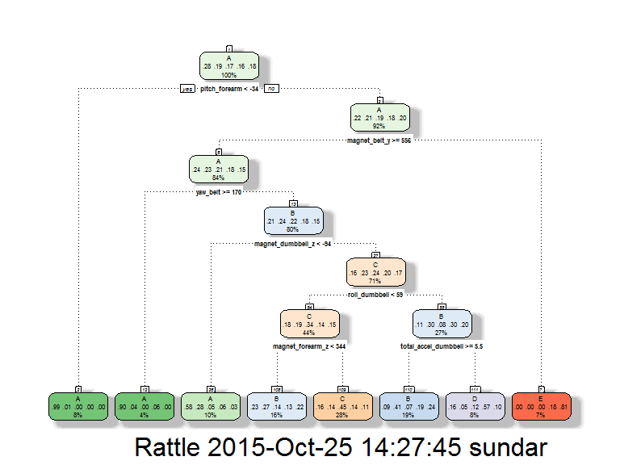

```r
#Plot using rattle.
fancyRpartPlot(modFit$finalModel)
```

The prediction accuracy of the model is **0.5246415**. It is very poor. Given the above observation, an attempt is made to improve the model by adopting the Principal Component Analysis approach.

```r
# Build model, with pre-processing using Principal Component Analysis (pca)
PreProc <- preProcess(Training[, -32], method = "pca", thresh = 0.99)
TrainPCA <- predict(PreProc, Training[, -32])
modFitPCA<- train(Training$classe ~., data=TrainPCA, method="rpart")
print(modFitPCA$finalModel)
```

```
## n= 13737
##
## node), split, n, loss, yval, (yprob)
##       * denotes terminal node
##
##   1) root 13737 9831 A (0.28 0.19 0.17 0.16 0.18)
##     2) PC2< -4.237963 574   27 A (0.95 0.0017 0.016 0 0.03) *
##     3) PC2>=-4.237963 13163 9804 A (0.26 0.2 0.18 0.17 0.19)
##       6) PC5>=2.210831 1017  257 A (0.75 0.042 0.076 0.021 0.11) *
##       7) PC5< 2.210831 12146 9532 B (0.21 0.22 0.19 0.18 0.2)
##        14) PC16< 0.4810805 9827 7489 A (0.24 0.21 0.22 0.19 0.14)
##          28) PC22< -0.500441 1715 1038 A (0.39 0.33 0.097 0.061 0.11) *
##          29) PC22>=-0.500441 8112 6100 C (0.2 0.19 0.25 0.21 0.15)
##            58) PC7< 0.7679576 5874 4171 C (0.23 0.18 0.29 0.15 0.14)
##             116) PC4>=1.621359 1045  547 A (0.48 0.18 0.2 0.079 0.063) *
##             117) PC4< 1.621359 4829 3331 C (0.18 0.18 0.31 0.17 0.16)
##               234) PC9< 0.5399915 3484 2155 C (0.17 0.16 0.38 0.18 0.11) *
##               235) PC9>=0.5399915 1345  966 E (0.19 0.26 0.13 0.15 0.28) *
##            59) PC7>=0.7679576 2238 1415 D (0.14 0.2 0.14 0.37 0.15) *
##        15) PC16>=0.4810805 2319 1312 E (0.11 0.22 0.056 0.18 0.43) *
```

```r
#Verify the goodness of the model
Training.PredictionPCA=predict(modFitPCA,TrainPCA)
Prediction.MatrixPCA = with(TrainPCA,table(Training.PredictionPCA,Training$classe))
Prediction.AccuracyPCA <-sum(diag(Prediction.MatrixPCA))/sum(as.vector(Prediction.MatrixPCA))
Rpart.Output.PCA<-confusionMatrix(Training$classe, predict(modFitPCA, TrainPCA))
```

The use of PCA does not improve the model for the better, and therefore, it is decided to adopt the random forest model for prediction.

### *3.2 Random Forest Model*

```r
modFitRF<- train(Training$classe ~., data=Training, method="rf")
print(modFitRF$finalModel)
```

```
##
## Call:
##  randomForest(x = x, y = y, mtry = param$mtry)
##                Type of random forest: classification
##                      Number of trees: 500
## No. of variables tried at each split: 2
##
##         OOB estimate of  error rate: 0.76%
## Confusion matrix:
##      A    B    C    D    E  class.error
## A 3904    2    0    0    0 0.0005120328
## B   15 2633    9    0    1 0.0094055681
## C    0   19 2367   10    0 0.0121035058
## D    1    0   38 2209    4 0.0190941385
## E    0    0    2    4 2519 0.0023762376
```

Now test the model against the testing data set, for **cross-validation and out of sample errors**.

```r
confusionMatrix(Testing$classe, predict(modFitRF, Testing))
```

```
## Confusion Matrix and Statistics
##
##           Reference
## Prediction    A    B    C    D    E
##          A 1674    0    0    0    0
##          B    8 1126    3    0    2
##          C    0    5 1015    6    0
##          D    0    0   13  951    0
##          E    0    0    1    3 1078
##
## Overall Statistics
##
##                Accuracy : 0.993
##                  95% CI : (0.9906, 0.995)
##     No Information Rate : 0.2858
##     P-Value [Acc > NIR] : < 2.2e-16
##
##                   Kappa : 0.9912
##  Mcnemar's Test P-Value : NA
##
## Statistics by Class:
##
##                      Class: A Class: B Class: C Class: D Class: E
## Sensitivity            0.9952   0.9956   0.9835   0.9906   0.9981
## Specificity            1.0000   0.9973   0.9977   0.9974   0.9992
## Pos Pred Value         1.0000   0.9886   0.9893   0.9865   0.9963
## Neg Pred Value         0.9981   0.9989   0.9965   0.9982   0.9996
## Prevalence             0.2858   0.1922   0.1754   0.1631   0.1835
## Detection Rate         0.2845   0.1913   0.1725   0.1616   0.1832
## Detection Prevalence   0.2845   0.1935   0.1743   0.1638   0.1839
## Balanced Accuracy      0.9976   0.9964   0.9906   0.9940   0.9987
```

### *3.3 Validation*

Now apply the model to the validation dataset, and report the prediction.

```r
# Apply the model to the Validation dataset.
predict(modFitRF, ReadRawValidationData)
```

```
##  [1] B A B A A E D B A A B C B A E E A B B B
## Levels: A B C D E
```

## 4.0 CONCLUSIONS

A model for predicting the activity, persons do based on the accelerometer data is developed. The model adopted the random forest technique for classification, and it was found to be very accurate. The model was validated against a validation dataset, and the results from such validation has been reported.

## 5.0 REFERENCE

Data source taken from (http://groupware.les.inf.puc-rio.br/har)